# Bilger-Hans-ADA-DATA-REANALYSIS-ASSIGNMENT

Hans Bilger

April 9, 2019

## Introduction

#### I am reanalyzing data from the 2017 Behavior paper “Isolation call ontogeny in bat pups” by Engler et al. (2017). The authors look at the developmental trajectory of isolation call acoustics in the nectivorous bat species Glossophaga soricina. The authors studied 10 individuals in total. They solicited and recorded isolation calls from newborn bats in five day intervals over the first few weeks of life. They then measured a number of acoustic parameters in each calling bout and used a variety of analytical techniques (t-tests, linear mixed models, etc.) to trace how those parameters changed over time. They also used discriminant function analysis to test for an individual signature in the calls. Their results yielded strong support for the existence of such a signature, and showed significant ontogenetic change over time in a variety of acoustic variables. I will be reanalyzing the descriptive statistics, t-tests, and linear mixed models for this project.

### Engler et al. (2017) Table A2: Descriptive measurements

```r
# First I loaded in the raw data and took a quick look at some of the variables
library(readxl)
library(tidyverse)
```

```r
library(cowplot)
b <- Gsor_IC_PCA_DFA_without_ID_2_8_10_ <- read_excel("Gsor_IC_PCA & DFA(without ID 2,8,10).xlsx")
head(b)
```

```
## # A tibble: 6 x 84
##   individual    ID sex   session date  `file#` duration interval disttomax
##   <chr>      <dbl> <chr>   <dbl> <chr> <chr>      <dbl>    <dbl>     <dbl>
## 1 black-lig…     1 fema…       0 2016… SR_201…   0.0274   0.0847   0.0115
## 2 black-lig…     1 fema…       0 2016… SR_201…   0.0245   0.0569   0.0137
## 3 black-lig…     1 fema…       0 2016… SR_201…   0.0176   0.0514   0.00655
## 4 black-lig…     1 fema…       0 2016… SR_201…   0.0107  NA        0.00147
## 5 black-lig…     1 fema…       0 2016… SR_201…   0.0301   0.0769   0.00796
## 6 black-lig…     1 fema…       0 2016… SR_201…   0.0147   0.0511   0.00646
## # … with 75 more variables: peakfreqstart <dbl>, minfreqstart <dbl>,
## #   maxfreqstart <dbl>, bandwstart <dbl>, entropystart <dbl>,
## #   peakfreqend <dbl>, minfreqend <dbl>, maxfreqend <dbl>, bandwend <dbl>,
## #   entropyend <dbl>, peakfreqcentre <dbl>, minfreqcentre <dbl>,
## #   maxfreqcentre <dbl>, bandwcentre <dbl>, entropycentre <dbl>,
## #   peakfreqmean <dbl>, minfreqmean <dbl>, maxfreqmean <dbl>,
## #   bandwmean <dbl>, entropymean <dbl>, peakfreq0 <dbl>, minfreq0 <dbl>,
## #   maxfreq0 <dbl>, bandw0 <dbl>, entropy0 <dbl>, peakfreq1 <dbl>,
## #   minfreq1 <dbl>, maxfreq1 <dbl>, bandw1 <dbl>, entropy1 <dbl>,
## #   peakfreq2 <dbl>, minfreq2 <dbl>, maxfreq2 <dbl>, bandw2 <dbl>,
## #   entropy2 <dbl>, peakfreq3 <dbl>, minfreq3 <dbl>, maxfreq3 <dbl>,
## #   bandw3 <dbl>, entropy3 <dbl>, peakfreq4 <dbl>, minfreq4 <dbl>,
## #   maxfreq4 <dbl>, bandw4 <dbl>, entropy4 <dbl>, peakfreq5 <dbl>,
## #   minfreq5 <dbl>, maxfreq5 <dbl>, bandw5 <dbl>, entropy5 <dbl>,
## #   peakfreq6 <dbl>, minfreq6 <dbl>, maxfreq6 <dbl>, bandw6 <dbl>,
## #   entropy6 <dbl>, peakfreq7 <dbl>, minfreq7 <dbl>, maxfreq7 <dbl>,
## #   bandw7 <dbl>, entropy7 <dbl>, peakfreq8 <dbl>, minfreq8 <dbl>,
## #   maxfreq8 <dbl>, bandw8 <dbl>, entropy8 <dbl>, peakfreq9 <dbl>,
## #   minfreq9 <dbl>, maxfreq9 <dbl>, bandw9 <dbl>, entropy9 <dbl>,
## #   callcurv_1 <dbl>, callcurv_2 <dbl>, callcurv_3 <dbl>,
## #   callcurv_4 <dbl>, entropycurv_1 <dbl>
```

```r
# Then I adjusted units to match those in Table A2 from Engler et al. (2017)
b$duration <- 1000*b$duration
b$interval <- 1000*b$interval
b$disttomax <- 1000*b$disttomax
b$peakfreqstart <- b$peakfreqstart/1000
b$peakfreqend <- b$peakfreqend/1000
b$peakfreqcentre <- b$peakfreqcentre/1000
b$peakfreqmean <- b$peakfreqmean/1000
b$minfreqmean <- b$minfreqmean/1000
b$maxfreqmean  <- b$maxfreqmean/1000
b$bandwmean <- b$bandwmean/1000

# Then I used dplyr to reproduce Table A2
c <- b %>%
  group_by(ID, session) %>%
  summarise_at(vars(duration, interval, disttomax, peakfreqstart, peakfreqend, peakfreqcentre, peakfreqmean, minfreqmean, maxfreqmean, bandwmean, entropymean), funs(mean(., na.rm=TRUE))) %>%
  select('Pup ID'=1, Session=2, 'Duration (ms)'=3, 'Interval (ms)'=4, 'Disttomax (ms)'=5, 'Peak frequency start (kHz)'=6, 'Peak frequency end (kHz)'=7, 'Peak frequency centre (kHz)'=8, 'Peak frequency mean (kHz)'=9, 'Mean freq Min (kHz)'=10, 'Mean freq Max (kHz)'=11, 'Bandwidth (mean, kHz)'=12, 'Entropy (mean)'=13)
c %>%
  kable() %>%
  kable_styling()
```

| Pup ID | Session | Duration (ms) | Interval (ms) | Disttomax (ms) | Peak frequency start (kHz) | Peak frequency end (kHz) | Peak frequency centre (kHz) | Peak frequency mean (kHz) | Mean freq Min (kHz) | Mean freq Max (kHz) | Bandwidth (mean, kHz) | Entropy (mean) |
| --- | --- | --- | --- | --- | --- | --- | --- | --- | --- | --- | --- | --- |
| 1 | 0 | 18.876000 | 64.26889 | 6.796000 | 67.95967 | 39.77883 | 45.48934 | 45.52683 | 40.60058 | 60.16941 | 19.51358 | 0.3593530 |
| 1 | 1 | 22.085556 | 46.64833 | 6.706667 | 70.88738 | 43.38643 | 49.78969 | 47.89742 | 45.06078 | 61.22791 | 16.11118 | 0.3488822 |
| 1 | 2 | 21.828333 | 50.50200 | 13.943333 | 73.46250 | 52.05833 | 53.47362 | 55.90348 | 50.33750 | 66.68958 | 16.30000 | 0.3049583 |
| 1 | 3 | 18.979000 | 52.81286 | 7.994000 | 72.33309 | 49.00381 | 50.92071 | 53.53857 | 47.05690 | 63.75167 | 16.64071 | 0.3358810 |
| 2 | 0 | 8.747500 | 38.45875 | 2.446250 | 61.51344 | 31.54531 | 40.13301 | 47.59351 | 35.75791 | 61.32008 | 25.51582 | 0.3825562 |
| 3 | 0 | 5.983333 | 49.00667 | 2.145833 | 55.88757 | 30.32708 | 41.15462 | 45.43538 | 35.48915 | 56.24571 | 20.71263 | 0.3700642 |
| 3 | 1 | 3.776000 | 52.59900 | 1.583000 | 76.87990 | 49.89550 | 63.39217 | 65.08020 | 53.54822 | 78.19885 | 24.59921 | 0.3573830 |
| 3 | 2 | 4.200909 | 42.98091 | 1.707273 | 77.10294 | 44.52695 | 55.85723 | 58.87179 | 46.24904 | 76.98623 | 30.68475 | 0.4188255 |
| 3 | 3 | 2.935000 | 40.22200 | 1.450000 | 78.12987 | 49.63805 | 60.61917 | 61.46500 | 52.87695 | 76.22250 | 23.28888 | 0.3879300 |
| 3 | 4 | 2.657143 | 31.96143 | 1.281429 | 74.33826 | 53.26984 | 63.55119 | 63.19254 | 55.34763 | 77.69771 | 22.32659 | 0.3871943 |
| 4 | 0 | 8.811429 | 45.75714 | 3.240000 | 53.75606 | 27.42000 | 37.05284 | 41.46081 | 30.46213 | 53.98444 | 23.47340 | 0.3302957 |
| 4 | 1 | 7.883333 | 41.90000 | 2.488333 | 65.24005 | 36.69893 | 45.13867 | 52.09480 | 38.45895 | 63.09627 | 24.59488 | 0.3542417 |
| 4 | 2 | 7.458000 | 47.27400 | 3.388000 | 68.22368 | 37.41748 | 49.71708 | 55.68318 | 41.26922 | 67.86062 | 26.54732 | 0.3715240 |
| 5 | 0 | 9.386250 | 38.46143 | 3.925000 | 56.69127 | 33.18234 | 38.74574 | 41.74428 | 34.99189 | 55.35269 | 20.32193 | 0.3420112 |
| 5 | 1 | 7.970000 | 30.87333 | 4.906667 | 63.33847 | 38.15083 | 41.92737 | 44.19340 | 39.19530 | 57.18507 | 17.95193 | 0.3672833 |
| 5 | 2 | 9.030000 | 34.00000 | 5.010000 | 70.08330 | 45.89580 | 50.02500 | 54.57500 | 44.72500 | 66.36670 | 21.60000 | 0.3825000 |
| 5 | 3 | 7.766667 | 32.69000 | 2.650000 | 69.05690 | 42.98287 | 49.51597 | 56.10070 | 44.86500 | 67.27430 | 22.36213 | 0.4057567 |
| 6 | 0 | 22.175556 | 74.62000 | 11.273333 | 63.61444 | 34.37962 | 45.11852 | 47.98463 | 39.10648 | 56.63796 | 17.48056 | 0.3366811 |
| 6 | 1 | 19.682000 | 49.82400 | 11.196000 | 65.88552 | 31.33110 | 43.52929 | 44.48581 | 37.63953 | 55.68629 | 18.00747 | 0.3515560 |
| 6 | 2 | 28.660000 | 62.09000 | 16.582000 | 66.84667 | 29.21667 | 46.00000 | 44.56667 | 39.60000 | 53.71667 | 14.06333 | 0.3642330 |
| 7 | 0 | 6.022000 | 39.33200 | 1.732000 | 63.50942 | 40.60778 | 47.04274 | 51.40834 | 42.91254 | 62.83910 | 19.86666 | 0.3253920 |
| 7 | 1 | 6.040000 | 39.53667 | 1.621667 | 68.97713 | 40.53918 | 48.26300 | 56.10525 | 44.35953 | 70.45133 | 26.03720 | 0.3898317 |
| 7 | 2 | 7.123750 | 39.15750 | 2.713750 | 72.17069 | 43.02996 | 48.23180 | 52.55304 | 43.23999 | 67.07394 | 23.78639 | 0.3872300 |
| 7 | 3 | 5.330000 | 28.40000 | 2.972000 | 80.30166 | 48.99866 | 55.41400 | 56.84866 | 48.24834 | 72.68134 | 24.39466 | 0.3921500 |
| 7 | 4 | 7.645000 | 29.88600 | 3.068333 | 61.58828 | 34.59422 | 42.09730 | 44.45370 | 36.11147 | 56.74290 | 20.59335 | 0.3576933 |
| 7 | 5 | 4.617500 | 23.41667 | 1.645000 | 64.66785 | 33.42768 | 44.72767 | 51.07142 | 40.43035 | 65.54552 | 25.08928 | 0.3895350 |
| 8 | 0 | 10.743000 | 52.78000 | 5.065000 | 52.11188 | 32.62450 | 38.84063 | 39.91930 | 33.03952 | 50.31889 | 17.24226 | 0.3747930 |
| 9 | 0 | 7.991429 | 40.07571 | 2.410000 | 57.65766 | 26.76257 | 39.30209 | 44.73307 | 33.12851 | 55.60760 | 22.43763 | 0.3721314 |
| 9 | 1 | 7.645000 | 30.06300 | 3.574000 | 65.58347 | 32.02789 | 42.42666 | 42.30293 | 34.68409 | 58.56883 | 23.83349 | 0.3983070 |
| 9 | 2 | 8.012222 | 32.96556 | 3.828889 | 63.62927 | 31.74147 | 40.40921 | 40.95160 | 33.17663 | 55.33949 | 22.11112 | 0.3956133 |
| 9 | 3 | 8.949000 | 33.49600 | 4.121000 | 63.88434 | 31.19674 | 40.15486 | 42.00937 | 33.71662 | 57.47072 | 23.70226 | 0.3776400 |
| 10 | 0 | 7.561429 | 29.85143 | 3.355714 | 73.75774 | 41.39107 | 49.20833 | 52.52679 | 43.00476 | 68.97321 | 25.92380 | 0.3978271 |
| 10 | 1 | 13.080000 | 40.92000 | 5.606667 | 64.22777 | 42.21110 | 53.31110 | 54.66110 | 48.59443 | 64.00557 | 15.39443 | 0.3156667 |

#### And here is the table from the original paper (split across two images).

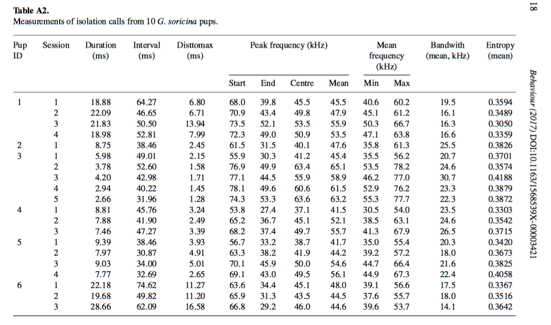

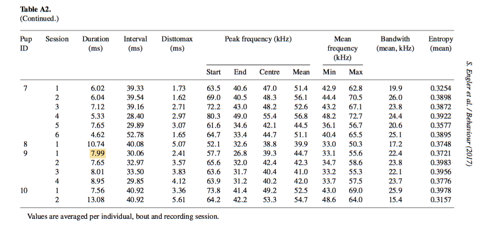

### Engler et al. (2017) Table A3: T-tests

```r
# T tests
library(readxl)
library(tidyverse)
a <- read_excel("Gsor_IC_t-test_sex diff (all 10 pups).xlsx")

# duration
male <- filter(a, sex=="male")
female <- filter(a, sex=="female")
female$duration <- 1000*female$duration
male$duration <- 1000*male$duration
t_dur <- t.test(female$duration, male$duration, paired=FALSE, var.equal = TRUE)
t_df <- nrow(male) + nrow(female) - 2

mean_dur_m <- mean(male$duration)
mean_dur_f <- mean(female$duration)
means_dur <- c(mean_dur_f, mean_dur_m)
diff.means_dur <- mean_dur_f - mean_dur_m
sd_f <- sd(female$duration)
sd_m <- sd(male$duration)
n_f <- 5
n_m <- 5

var.pooled <- function(df1,df2,SD1,SD2){
  (df1*SD1^2 + df2*SD2^2)/(df1+df2)
}

var.pooled_dur <- var.pooled(4, 4, sd(female$duration), sd(male$duration))

SE.diff <- function(var.pool, n1,n2){
  sqrt(var.pool*(1/n1 + 1/n2))
}

SE.diff_dur <- SE.diff(var.pooled_dur, 5, 5)

df_dur <- c((t_dur$statistic), t_df, t_dur$p.value, diff.means_dur, SE.diff_dur, t_dur$conf.int)
df_dur <- matrix(df_dur, ncol=7)
df_dur <- as.data.frame(df_dur)
df_dur <- select(df_dur, t=1, df=2, "p-value"=3, "mean difference"=4, "SE of difference"=5, "95% CI of difference, lower"=6, "95% CI of difference, upper"=7)
row.names(df_dur)[dim(df_dur)[1]] <- "Duration (ms)"
df_dur
```

```
##                        t df   p-value mean difference SE of difference
## Duration (ms) -0.3884464  8 0.7078189        -1.58852         4.089419
##               95% CI of difference, lower 95% CI of difference, upper
## Duration (ms)                   -11.01874                    7.841698
```

```r
# interval

female$interval <- 1000*female$interval
male$interval <- 1000*male$interval
t_int <- t.test(female$interval, male$interval, var.equal = TRUE, paired=FALSE)
t_df <- nrow(male) + nrow(female) - 2

mean_int_m <- mean(male$interval)
mean_int_f <- mean(female$interval)
means_int <- c(mean_int_f, mean_int_m)
diff.means_int <- mean_int_f - mean_int_m

var.pooled <- function(df1,df2,SD1,SD2){
  (df1*SD1^2 + df2*SD2^2)/(df1+df2)
}

var.pooled_int <- var.pooled(4, 4, sd(female$interval), sd(male$interval))

SE.diff <- function(var.pool, n1,n2){
  sqrt(var.pool*(1/n1 + 1/n2))
}

SE.diff_int <- SE.diff(var.pooled_int, 5, 5)

df_int <- c((t_int$statistic), t_df, t_int$p.value, diff.means_int, SE.diff_int, t_int$conf.int)
df_int <- matrix(df_int, ncol=7)
df_int <- as.data.frame(df_int)
df_int <- select(df_int, t=1, df=2, "p-value"=3, "mean difference"=4, "SE of difference"=5, "95% CI of difference, lower"=6, "95% CI of difference, upper"=7)
row.names(df_int)[dim(df_int)[1]] <- "Interval (ms)"
df_int
```

```
##                        t df   p-value mean difference SE of difference
## Interval (ms) 0.01882146  8 0.9854445         0.13978         7.426628
##               95% CI of difference, lower 95% CI of difference, upper
## Interval (ms)                   -16.98605                    17.26561
```

```r
# Time to max. amplitude (ms)

female$disttomax <- 1000*female$disttomax
male$disttomax <- 1000*male$disttomax
t_disttomax <- t.test(female$disttomax, male$disttomax, var.equal = TRUE, paired=FALSE)
t_df <- nrow(male) + nrow(female) - 2

mean_disttomax_m <- mean(male$disttomax)
mean_disttomax_f <- mean(female$disttomax)
means_disttomax <- c(mean_disttomax_f, mean_disttomax_m)
diff.means_disttomax <- mean_disttomax_f - mean_disttomax_m

var.pooled <- function(df1,df2,SD1,SD2){
  (df1*SD1^2 + df2*SD2^2)/(df1+df2)
}

var.pooled_disttomax <- var.pooled(4, 4, sd(female$disttomax), sd(male$disttomax))

SE.diff <- function(var.pool, n1,n2){
  sqrt(var.pool*(1/n1 + 1/n2))
}

SE.diff_disttomax <- SE.diff(var.pooled_disttomax, 5, 5)

df_disttomax <- c((t_disttomax$statistic), t_df, t_disttomax$p.value, diff.means_disttomax, SE.diff_disttomax, t_disttomax$conf.int)
df_disttomax <- matrix(df_disttomax, ncol=7)
df_disttomax <- as.data.frame(df_disttomax)
df_disttomax <- select(df_disttomax, t=1, df=2, "p-value"=3, "mean difference"=4, "SE of difference"=5, "95% CI of difference, lower"=6, "95% CI of difference, upper"=7)
row.names(df_disttomax)[dim(df_disttomax)[1]] <- "Time to max. amplitude (ms)"
df_disttomax
```

```
##                                      t df  p-value mean difference
## Time to max. amplitude (ms) -0.7693068  8 0.463817         -1.7271
##                             SE of difference 95% CI of difference, lower
## Time to max. amplitude (ms)         2.245008                   -6.904098
##                             95% CI of difference, upper
## Time to max. amplitude (ms)                    3.449898
```

```r
# Peak frequency (start) (kHz)
female$peakfreqstart <- female$peakfreqstart/1000
male$peakfreqstart <- male$peakfreqstart/1000
t_peakfreqstart <- t.test(female$peakfreqstart, male$peakfreqstart, paired=FALSE, var.equal = TRUE)
t_df <- nrow(male) + nrow(female) - 2

mean_peakfreqstart_m <- mean(male$peakfreqstart)
mean_peakfreqstart_f <- mean(female$peakfreqstart)
means_peakfreqstart <- c(mean_peakfreqstart_f, mean_peakfreqstart_m)
diff.means_peakfreqstart <- mean_peakfreqstart_f - mean_peakfreqstart_m

var.pooled <- function(df1,df2,SD1,SD2){
  (df1*SD1^2 + df2*SD2^2)/(df1+df2)
}

var.pooled_peakfreqstart <- var.pooled(4, 4, sd(female$peakfreqstart), sd(male$peakfreqstart))

SE.diff <- function(var.pool, n1,n2){
  sqrt(var.pool*(1/n1 + 1/n2))
}

SE.diff_peakfreqstart <- SE.diff(var.pooled_peakfreqstart, 5, 5)

df_peakfreqstart <- c((t_peakfreqstart$statistic), t_df, t_peakfreqstart$p.value, diff.means_peakfreqstart, SE.diff_peakfreqstart, t_peakfreqstart$conf.int)
df_peakfreqstart <- matrix(df_peakfreqstart, ncol=7)
df_peakfreqstart <- as.data.frame(df_peakfreqstart)
df_peakfreqstart <- select(df_peakfreqstart, t=1, df=2, "p-value"=3, "mean difference"=4, "SE of difference"=5, "95% CI of difference, lower"=6, "95% CI of difference, upper"=7)
row.names(df_peakfreqstart)[dim(df_peakfreqstart)[1]] <- "Peak frequency (start) (kHz)"
df_peakfreqstart
```

```
##                                      t df   p-value mean difference
## Peak frequency (start) (kHz) 0.3105803  8 0.7640573        1.251604
##                              SE of difference 95% CI of difference, lower
## Peak frequency (start) (kHz)         4.029889                   -8.041337
##                              95% CI of difference, upper
## Peak frequency (start) (kHz)                    10.54455
```

```r
# Peak freq (end) (kHz)
female$peakfreqend <- female$peakfreqend/1000
male$peakfreqend <- male$peakfreqend/1000
t_peakfreqend <- t.test(female$peakfreqend, male$peakfreqend, paired=FALSE, var.equal = TRUE)
t_df <- nrow(male) + nrow(female) - 2

mean_peakfreqend_m <- mean(male$peakfreqend)
mean_peakfreqend_f <- mean(female$peakfreqend)
means_peakfreqend <- c(mean_peakfreqend_f, mean_peakfreqend_m)
diff.means_peakfreqend <- mean_peakfreqend_f - mean_peakfreqend_m

var.pooled <- function(df1,df2,SD1,SD2){
  (df1*SD1^2 + df2*SD2^2)/(df1+df2)
}

var.pooled_peakfreqend <- var.pooled(4, 4, sd(female$peakfreqend), sd(male$peakfreqend))

SE.diff <- function(var.pool, n1,n2){
  sqrt(var.pool*(1/n1 + 1/n2))
}

SE.diff_peakfreqend <- SE.diff(var.pooled_peakfreqend, 5, 5)

df_peakfreqend <- c((t_peakfreqend$statistic), t_df, t_peakfreqend$p.value, diff.means_peakfreqend, SE.diff_peakfreqend, t_peakfreqend$conf.int)
df_peakfreqend <- matrix(df_peakfreqend, ncol=7)
df_peakfreqend <- as.data.frame(df_peakfreqend)
df_peakfreqend <- select(df_peakfreqend, t=1, df=2, "p-value"=3, "mean difference"=4, "SE of difference"=5, "95% CI of difference, lower"=6, "95% CI of difference, upper"=7)
row.names(df_peakfreqend)[dim(df_peakfreqend)[1]] <- "Peak frequency (end) (kHz)"
df_peakfreqend
```

```
##                                    t df   p-value mean difference
## Peak frequency (end) (kHz) 0.7823726  8 0.4565264        2.849657
##                            SE of difference 95% CI of difference, lower
## Peak frequency (end) (kHz)         3.642326                   -5.549563
##                            95% CI of difference, upper
## Peak frequency (end) (kHz)                    11.24888
```

```r
# Peak frequency (centre) (kHz)

female$peakfreqcentre <- female$peakfreqcentre/1000
male$peakfreqcentre <- male$peakfreqcentre/1000
t_peakfreqcentre <- t.test(female$peakfreqcentre, male$peakfreqcentre, paired=FALSE, var.equal = TRUE)
t_df <- nrow(male) + nrow(female) - 2

mean_peakfreqcentre_m <- mean(male$peakfreqcentre)
mean_peakfreqcentre_f <- mean(female$peakfreqcentre)
means_peakfreqcentre <- c(mean_peakfreqcentre_f, mean_peakfreqcentre_m)
diff.means_peakfreqcentre <- mean_peakfreqcentre_f - mean_peakfreqcentre_m

var.pooled <- function(df1,df2,SD1,SD2){
  (df1*SD1^2 + df2*SD2^2)/(df1+df2)
}

var.pooled_peakfreqcentre <- var.pooled(4, 4, sd(female$peakfreqcentre), sd(male$peakfreqcentre))

SE.diff <- function(var.pool, n1,n2){
  sqrt(var.pool*(1/n1 + 1/n2))
}

SE.diff_peakfreqcentre <- SE.diff(var.pooled_peakfreqcentre, 5, 5)

df_peakfreqcentre <- c((t_peakfreqcentre$statistic), t_df, t_peakfreqcentre$p.value, diff.means_peakfreqcentre, SE.diff_peakfreqcentre, t_peakfreqcentre$conf.int)
df_peakfreqcentre <- matrix(df_peakfreqcentre, ncol=7)
df_peakfreqcentre <- as.data.frame(df_peakfreqcentre)
df_peakfreqcentre <- select(df_peakfreqcentre, t=1, df=2, "p-value"=3, "mean difference"=4, "SE of difference"=5, "95% CI of difference, lower"=6, "95% CI of difference, upper"=7)
row.names(df_peakfreqcentre)[dim(df_peakfreqcentre)[1]] <- "Peak frequency (centre) (kHz)"
df_peakfreqcentre
```

```
##                                       t df   p-value mean difference
## Peak frequency (centre) (kHz) 0.4643317  8 0.6547846        1.638536
##                               SE of difference 95% CI of difference, lower
## Peak frequency (centre) (kHz)         3.528806                   -6.498905
##                               95% CI of difference, upper
## Peak frequency (centre) (kHz)                    9.775978
```

```r
# Peak freqency (mean) (kHz)

female$peakfreqmean <- female$peakfreqmean/1000
male$peakfreqmean <- male$peakfreqmean/1000
t_peakfreqmean <- t.test(female$peakfreqmean, male$peakfreqmean, paired=FALSE, var.equal = TRUE)
t_df <- nrow(male) + nrow(female) - 2

mean_peakfreqmean_m <- mean(male$peakfreqmean)
mean_peakfreqmean_f <- mean(female$peakfreqmean)
means_peakfreqmean <- c(mean_peakfreqmean_f, mean_peakfreqmean_m)
diff.means_peakfreqmean <- mean_peakfreqmean_f - mean_peakfreqmean_m

var.pooled <- function(df1,df2,SD1,SD2){
  (df1*SD1^2 + df2*SD2^2)/(df1+df2)
}

var.pooled_peakfreqmean <- var.pooled(4, 4, sd(female$peakfreqmean), sd(male$peakfreqmean))

SE.diff <- function(var.pool, n1,n2){
  sqrt(var.pool*(1/n1 + 1/n2))
}

SE.diff_peakfreqmean <- SE.diff(var.pooled_peakfreqmean, 5, 5)

df_peakfreqmean <- c((t_peakfreqmean$statistic), t_df, t_peakfreqmean$p.value, diff.means_peakfreqmean, SE.diff_peakfreqmean, t_peakfreqmean$conf.int)
df_peakfreqmean <- matrix(df_peakfreqmean, ncol=7)
df_peakfreqmean <- as.data.frame(df_peakfreqmean)
df_peakfreqmean <- select(df_peakfreqmean, t=1, df=2, "p-value"=3, "mean difference"=4, "SE of difference"=5, "95% CI of difference, lower"=6, "95% CI of difference, upper"=7)
row.names(df_peakfreqmean)[dim(df_peakfreqmean)[1]] <- "Peak frequency (mean) (kHz)"
df_peakfreqmean
```

```
##                                   t df   p-value mean difference
## Peak frequency (mean) (kHz) 1.04825  8 0.3251572        3.469025
##                             SE of difference 95% CI of difference, lower
## Peak frequency (mean) (kHz)          3.30935                   -4.162349
##                             95% CI of difference, upper
## Peak frequency (mean) (kHz)                     11.1004
```

```r
# Min frequency (mean) (kHz)

female$minfreqmean <- female$minfreqmean/1000
male$minfreqmean <- male$minfreqmean/1000
t_minfreqmean <- t.test(female$minfreqmean, male$minfreqmean, paired=FALSE, var.equal = TRUE)
t_df <- nrow(male) + nrow(female) - 2

mean_minfreqmean_m <- mean(male$minfreqmean)
mean_minfreqmean_f <- mean(female$minfreqmean)
means_minfreqmean <- c(mean_minfreqmean_f, mean_minfreqmean_m)
diff.means_minfreqmean <- mean_minfreqmean_f - mean_minfreqmean_m

var.pooled <- function(df1,df2,SD1,SD2){
  (df1*SD1^2 + df2*SD2^2)/(df1+df2)
}

var.pooled_minfreqmean <- var.pooled(4, 4, sd(female$minfreqmean), sd(male$minfreqmean))

SE.diff <- function(var.pool, n1,n2){
  sqrt(var.pool*(1/n1 + 1/n2))
}

SE.diff_minfreqmean <- SE.diff(var.pooled_minfreqmean, 5, 5)

df_minfreqmean <- c((t_minfreqmean$statistic), t_df, t_minfreqmean$p.value, diff.means_minfreqmean, SE.diff_minfreqmean, t_minfreqmean$conf.int)
df_minfreqmean <- matrix(df_minfreqmean, ncol=7)
df_minfreqmean <- as.data.frame(df_minfreqmean)
df_minfreqmean <- select(df_minfreqmean, t=1, df=2, "p-value"=3, "mean difference"=4, "SE of difference"=5, "95% CI of difference, lower"=6, "95% CI of difference, upper"=7)
row.names(df_minfreqmean)[dim(df_minfreqmean)[1]] <- "Min frequency (mean) (kHz)"
df_minfreqmean
```

```
##                                    t df   p-value mean difference
## Min frequency (mean) (kHz) 0.6081377  8 0.5599609        2.023516
##                            SE of difference 95% CI of difference, lower
## Min frequency (mean) (kHz)         3.327398                   -5.649478
##                            95% CI of difference, upper
## Min frequency (mean) (kHz)                     9.69651
```

```r
# Max frequency (mean) (kHz)

female$maxfreqmean <- female$maxfreqmean/1000
male$maxfreqmean <- male$maxfreqmean/1000
t_maxfreqmean <- t.test(female$maxfreqmean, male$maxfreqmean, paired=FALSE, var.equal = TRUE)
t_df <- nrow(male) + nrow(female) - 2

mean_maxfreqmean_m <- mean(male$maxfreqmean)
mean_maxfreqmean_f <- mean(female$maxfreqmean)
means_maxfreqmean <- c(mean_maxfreqmean_f, mean_maxfreqmean_m)
diff.means_maxfreqmean <- mean_maxfreqmean_f - mean_maxfreqmean_m

var.pooled <- function(df1,df2,SD1,SD2){
  (df1*SD1^2 + df2*SD2^2)/(df1+df2)
}

var.pooled_maxfreqmean <- var.pooled(4, 4, sd(female$maxfreqmean), sd(male$maxfreqmean))

SE.diff <- function(var.pool, n1,n2){
  sqrt(var.pool*(1/n1 + 1/n2))
}

SE.diff_maxfreqmean <- SE.diff(var.pooled_maxfreqmean, 5, 5)

df_maxfreqmean <- c((t_maxfreqmean$statistic), t_df, t_maxfreqmean$p.value, diff.means_maxfreqmean, SE.diff_maxfreqmean, t_maxfreqmean$conf.int)
df_maxfreqmean <- matrix(df_maxfreqmean, ncol=7)
df_maxfreqmean <- as.data.frame(df_maxfreqmean)
df_maxfreqmean <- select(df_maxfreqmean, t=1, df=2, "p-value"=3, "mean difference"=4, "SE of difference"=5, "95% CI of difference, lower"=6, "95% CI of difference, upper"=7)
row.names(df_maxfreqmean)[dim(df_maxfreqmean)[1]] <- "Max frequency (mean) (kHz)"
df_maxfreqmean
```

```
##                                    t df   p-value mean difference
## Max frequency (mean) (kHz) 0.9873717  8 0.3523784        3.922203
##                            SE of difference 95% CI of difference, lower
## Max frequency (mean) (kHz)         3.972367                   -5.238091
##                            95% CI of difference, upper
## Max frequency (mean) (kHz)                     13.0825
```

```r
# Bandwidth (mean) (kHz)

female$bandwmean <- female$bandwmean/1000
male$bandwmean <- male$bandwmean/1000
t_bandwmean <- t.test(female$bandwmean, male$bandwmean, paired=FALSE, var.equal = TRUE)
t_df <- nrow(male) + nrow(female) - 2

mean_bandwmean_m <- mean(male$bandwmean)
mean_bandwmean_f <- mean(female$bandwmean)
means_bandwmean <- c(mean_bandwmean_f, mean_bandwmean_m)
diff.means_bandwmean <- mean_bandwmean_f - mean_bandwmean_m

var.pooled <- function(df1,df2,SD1,SD2){
  (df1*SD1^2 + df2*SD2^2)/(df1+df2)
}

var.pooled_bandwmean <- var.pooled(4, 4, sd(female$bandwmean), sd(male$bandwmean))

SE.diff <- function(var.pool, n1,n2){
  sqrt(var.pool*(1/n1 + 1/n2))
}

SE.diff_bandwmean <- SE.diff(var.pooled_bandwmean, 5, 5)

df_bandwmean <- c((t_bandwmean$statistic), t_df, t_bandwmean$p.value, diff.means_bandwmean, SE.diff_bandwmean, t_bandwmean$conf.int)
df_bandwmean <- matrix(df_bandwmean, ncol=7)
df_bandwmean <- as.data.frame(df_bandwmean)
df_bandwmean <- select(df_bandwmean, t=1, df=2, "p-value"=3, "mean difference"=4, "SE of difference"=5, "95% CI of difference, lower"=6, "95% CI of difference, upper"=7)
row.names(df_bandwmean)[dim(df_bandwmean)[1]] <- "Bandwidth (mean) (kHz)"
df_bandwmean
```

```
##                                t df   p-value mean difference
## Bandwidth (mean) (kHz) 0.8631788  8 0.4131672        1.895254
##                        SE of difference 95% CI of difference, lower
## Bandwidth (mean) (kHz)         2.195668                   -3.167966
##                        95% CI of difference, upper
## Bandwidth (mean) (kHz)                    6.958475
```

```r
# Entropy (mean)

t_entropymean <- t.test(female$entropymean, male$entropymean, paired=FALSE, var.equal = TRUE)
t_df <- nrow(male) + nrow(female) - 2

mean_entropymean_m <- mean(male$entropymean)
mean_entropymean_f <- mean(female$entropymean)
means_entropymean <- c(mean_entropymean_f, mean_entropymean_m)
diff.means_entropymean <- mean_entropymean_f - mean_entropymean_m

var.pooled <- function(df1,df2,SD1,SD2){
  (df1*SD1^2 + df2*SD2^2)/(df1+df2)
}

var.pooled_entropymean <- var.pooled(4, 4, sd(female$entropymean), sd(male$entropymean))

SE.diff <- function(var.pool, n1,n2){
  sqrt(var.pool*(1/n1 + 1/n2))
}

SE.diff_entropymean <- SE.diff(var.pooled_entropymean, 5, 5)

df_entropymean <- c((t_entropymean$statistic), t_df, t_entropymean$p.value, diff.means_entropymean, SE.diff_entropymean, t_entropymean$conf.int)
df_entropymean <- matrix(df_entropymean, ncol=7)
df_entropymean <- as.data.frame(df_entropymean)
df_entropymean <- select(df_entropymean, t=1, df=2, "p-value"=3, "mean difference"=4, "SE of difference"=5, "95% CI of difference, lower"=6, "95% CI of difference, upper"=7)
row.names(df_entropymean)[dim(df_entropymean)[1]] <- "Entropy (mean)"
df_entropymean
```

```
##                         t df p-value mean difference SE of difference
## Entropy (mean) -0.7925521  8  0.4509     -0.00822584       0.01037893
##                95% CI of difference, lower 95% CI of difference, upper
## Entropy (mean)                 -0.03215969                  0.01570801
```

```r
# Frequency curvature 1

t_callcurvature1PC1 <- t.test(female$callcurvature1PC1, male$callcurvature1PC1, paired=FALSE, var.equal = TRUE)
t_df <- nrow(male) + nrow(female) - 2

mean_callcurvature1PC1_m <- mean(male$callcurvature1PC1)
mean_callcurvature1PC1_f <- mean(female$callcurvature1PC1)
means_callcurvature1PC1 <- c(mean_callcurvature1PC1_f, mean_callcurvature1PC1_m)
diff.means_callcurvature1PC1 <- mean_callcurvature1PC1_f - mean_callcurvature1PC1_m

var.pooled <- function(df1,df2,SD1,SD2){
  (df1*SD1^2 + df2*SD2^2)/(df1+df2)
}

var.pooled_callcurvature1PC1 <- var.pooled(4, 4, sd(female$callcurvature1PC1), sd(male$callcurvature1PC1))

SE.diff <- function(var.pool, n1,n2){
  sqrt(var.pool*(1/n1 + 1/n2))
}

SE.diff_callcurvature1PC1 <- SE.diff(var.pooled_callcurvature1PC1, 5, 5)

df_callcurvature1PC1 <- c((t_callcurvature1PC1$statistic), t_df, t_callcurvature1PC1$p.value, diff.means_callcurvature1PC1, SE.diff_callcurvature1PC1, t_callcurvature1PC1$conf.int)
df_callcurvature1PC1 <- matrix(df_callcurvature1PC1, ncol=7)
df_callcurvature1PC1 <- as.data.frame(df_callcurvature1PC1)
df_callcurvature1PC1 <- select(df_callcurvature1PC1, t=1, df=2, "p-value"=3, "mean difference"=4, "SE of difference"=5, "95% CI of difference, lower"=6, "95% CI of difference, upper"=7)
row.names(df_callcurvature1PC1)[dim(df_callcurvature1PC1)[1]] <- "Frequency curvature 1"
df_callcurvature1PC1
```

```
##                               t df   p-value mean difference
## Frequency curvature 1 0.6835966  8 0.5135386       0.2701843
##                       SE of difference 95% CI of difference, lower
## Frequency curvature 1        0.3952393                  -0.6412393
##                       95% CI of difference, upper
## Frequency curvature 1                    1.181608
```

```r
# Frequency curvature 2

t_callcurvature2PC2 <- t.test(female$callcurvature2PC2, male$callcurvature2PC2, paired=FALSE, var.equal = TRUE)
t_df <- nrow(male) + nrow(female) - 2

mean_callcurvature2PC2_m <- mean(male$callcurvature2PC2)
mean_callcurvature2PC2_f <- mean(female$callcurvature2PC2)
means_callcurvature2PC2 <- c(mean_callcurvature2PC2_f, mean_callcurvature2PC2_m)
diff.means_callcurvature2PC2 <- mean_callcurvature2PC2_f - mean_callcurvature2PC2_m

var.pooled <- function(df1,df2,SD1,SD2){
  (df1*SD1^2 + df2*SD2^2)/(df1+df2)
}

var.pooled_callcurvature2PC2 <- var.pooled(4, 4, sd(female$callcurvature2PC2), sd(male$callcurvature2PC2))

SE.diff <- function(var.pool, n1,n2){
  sqrt(var.pool*(1/n1 + 1/n2))
}

SE.diff_callcurvature2PC2 <- SE.diff(var.pooled_callcurvature2PC2, 5, 5)

df_callcurvature2PC2 <- c((t_callcurvature2PC2$statistic), t_df, t_callcurvature2PC2$p.value, diff.means_callcurvature2PC2, SE.diff_callcurvature2PC2, t_callcurvature2PC2$conf.int)
df_callcurvature2PC2 <- matrix(df_callcurvature2PC2, ncol=7)
df_callcurvature2PC2 <- as.data.frame(df_callcurvature2PC2)
df_callcurvature2PC2 <- select(df_callcurvature2PC2, t=1, df=2, "p-value"=3, "mean difference"=4, "SE of difference"=5, "95% CI of difference, lower"=6, "95% CI of difference, upper"=7)
row.names(df_callcurvature2PC2)[dim(df_callcurvature2PC2)[1]] <- "Frequency curvature 2"
df_callcurvature2PC2
```

```
##                               t df   p-value mean difference
## Frequency curvature 2 0.2486191  8 0.8099188       0.1100137
##                       SE of difference 95% CI of difference, lower
## Frequency curvature 2        0.4424989                  -0.9103906
##                       95% CI of difference, upper
## Frequency curvature 2                    1.130418
```

```r
# Frequency curvature 3

t_callcurvature3PC3 <- t.test(female$callcurvature3PC3, male$callcurvature3PC3, paired=FALSE, var.equal = TRUE)
t_df <- nrow(male) + nrow(female) - 2

mean_callcurvature3PC3_m <- mean(male$callcurvature3PC3)
mean_callcurvature3PC3_f <- mean(female$callcurvature3PC3)
means_callcurvature3PC3 <- c(mean_callcurvature3PC3_f, mean_callcurvature3PC3_m)
diff.means_callcurvature3PC3 <- mean_callcurvature3PC3_f - mean_callcurvature3PC3_m

var.pooled <- function(df1,df2,SD1,SD2){
  (df1*SD1^2 + df2*SD2^2)/(df1+df2)
}

var.pooled_callcurvature3PC3 <- var.pooled(4, 4, sd(female$callcurvature3PC3), sd(male$callcurvature3PC3))

SE.diff <- function(var.pool, n1,n2){
  sqrt(var.pool*(1/n1 + 1/n2))
}

SE.diff_callcurvature3PC3 <- SE.diff(var.pooled_callcurvature3PC3, 5, 5)

df_callcurvature3PC3 <- c((t_callcurvature3PC3$statistic), t_df, t_callcurvature3PC3$p.value, diff.means_callcurvature3PC3, SE.diff_callcurvature3PC3, t_callcurvature3PC3$conf.int)
df_callcurvature3PC3 <- matrix(df_callcurvature3PC3, ncol=7)
df_callcurvature3PC3 <- as.data.frame(df_callcurvature3PC3)
df_callcurvature3PC3 <- select(df_callcurvature3PC3, t=1, df=2, "p-value"=3, "mean difference"=4, "SE of difference"=5, "95% CI of difference, lower"=6, "95% CI of difference, upper"=7)
row.names(df_callcurvature3PC3)[dim(df_callcurvature3PC3)[1]] <- "Frequency curvature 3"
df_callcurvature3PC3
```

```
##                                t df   p-value mean difference
## Frequency curvature 3 -0.1700144  8 0.8692196     -0.05826792
##                       SE of difference 95% CI of difference, lower
## Frequency curvature 3        0.3427233                  -0.8485894
##                       95% CI of difference, upper
## Frequency curvature 3                   0.7320535
```

```r
# Frequency curvature 4

t_callcurvature4PC4 <- t.test(female$callcurvature4PC4, male$callcurvature4PC4, paired=FALSE, var.equal = TRUE)
t_df <- nrow(male) + nrow(female) - 2

mean_callcurvature4PC4_m <- mean(male$callcurvature4PC4)
mean_callcurvature4PC4_f <- mean(female$callcurvature4PC4)
means_callcurvature4PC4 <- c(mean_callcurvature4PC4_f, mean_callcurvature4PC4_m)
diff.means_callcurvature4PC4 <- mean_callcurvature4PC4_f - mean_callcurvature4PC4_m

var.pooled <- function(df1,df2,SD1,SD2){
  (df1*SD1^2 + df2*SD2^2)/(df1+df2)
}

var.pooled_callcurvature4PC4 <- var.pooled(4, 4, sd(female$callcurvature4PC4), sd(male$callcurvature4PC4))

SE.diff <- function(var.pool, n1,n2){
  sqrt(var.pool*(1/n1 + 1/n2))
}

SE.diff_callcurvature4PC4 <- SE.diff(var.pooled_callcurvature4PC4, 5, 5)

df_callcurvature4PC4 <- c((t_callcurvature4PC4$statistic), t_df, t_callcurvature4PC4$p.value, diff.means_callcurvature4PC4, SE.diff_callcurvature4PC4, t_callcurvature4PC4$conf.int)
df_callcurvature4PC4 <- matrix(df_callcurvature4PC4, ncol=7)
df_callcurvature4PC4 <- as.data.frame(df_callcurvature4PC4)
df_callcurvature4PC4 <- select(df_callcurvature4PC4, t=1, df=2, "p-value"=3, "mean difference"=4, "SE of difference"=5, "95% CI of difference, lower"=6, "95% CI of difference, upper"=7)
row.names(df_callcurvature4PC4)[dim(df_callcurvature4PC4)[1]] <- "Frequency curvature 4"
df_callcurvature4PC4
```

```
##                                t df   p-value mean difference
## Frequency curvature 4 0.08288339  8 0.9359806      0.03028928
##                       SE of difference 95% CI of difference, lower
## Frequency curvature 4        0.3654445                  -0.8124272
##                       95% CI of difference, upper
## Frequency curvature 4                   0.8730058
```

```r
# Entropy curvature 1

t_entropycurvaturePC1 <- t.test(female$entropycurvaturePC1, male$entropycurvaturePC1, paired=FALSE, var.equal = TRUE)
t_df <- nrow(male) + nrow(female) - 2

mean_entropycurvaturePC1_m <- mean(male$entropycurvaturePC1)
mean_entropycurvaturePC1_f <- mean(female$entropycurvaturePC1)
means_entropycurvaturePC1 <- c(mean_entropycurvaturePC1_f, mean_entropycurvaturePC1_m)
diff.means_entropycurvaturePC1 <- mean_entropycurvaturePC1_f - mean_entropycurvaturePC1_m

var.pooled <- function(df1,df2,SD1,SD2){
  (df1*SD1^2 + df2*SD2^2)/(df1+df2)
}

var.pooled_entropycurvaturePC1 <- var.pooled(4, 4, sd(female$entropycurvaturePC1), sd(male$entropycurvaturePC1))

SE.diff <- function(var.pool, n1,n2){
  sqrt(var.pool*(1/n1 + 1/n2))
}

SE.diff_entropycurvaturePC1 <- SE.diff(var.pooled_entropycurvaturePC1, 5, 5)

df_entropycurvaturePC1 <- c((t_entropycurvaturePC1$statistic), t_df, t_entropycurvaturePC1$p.value, diff.means_entropycurvaturePC1, SE.diff_entropycurvaturePC1, t_entropycurvaturePC1$conf.int)
df_entropycurvaturePC1 <- matrix(df_entropycurvaturePC1, ncol=7)
df_entropycurvaturePC1 <- as.data.frame(df_entropycurvaturePC1)
df_entropycurvaturePC1 <- select(df_entropycurvaturePC1, t=1, df=2, "p-value"=3, "mean difference"=4, "SE of difference"=5, "95% CI of difference, lower"=6, "95% CI of difference, upper"=7)
row.names(df_entropycurvaturePC1)[dim(df_entropycurvaturePC1)[1]] <- "Entropy curvature 1"
df_entropycurvaturePC1
```

```
##                             t df   p-value mean difference
## Entropy curvature 1 0.2765195  8 0.7891588       0.1277514
##                     SE of difference 95% CI of difference, lower
## Entropy curvature 1         0.461998                  -0.9376179
##                     95% CI of difference, upper
## Entropy curvature 1                    1.193121
```

```r
# table
t_tests <- rbind(df_dur, df_int, df_disttomax, df_peakfreqstart, df_peakfreqend, df_peakfreqcentre, df_peakfreqmean, df_minfreqmean, df_maxfreqmean, df_bandwmean, df_entropymean, df_callcurvature1PC1, df_callcurvature2PC2, df_callcurvature3PC3, df_callcurvature4PC4, df_entropycurvaturePC1)

t_tests %>%
  kable() %>%
  kable_styling
```

|  | t | df | p-value | mean difference | SE of difference | 95% CI of difference, lower | 95% CI of difference, upper |
| --- | --- | --- | --- | --- | --- | --- | --- |
| Duration (ms) | -0.3884464 | 8 | 0.7078189 | -1.5885200 | 4.0894193 | -11.0187377 | 7.8416977 |
| Interval (ms) | 0.0188215 | 8 | 0.9854445 | 0.1397800 | 7.4266275 | -16.9860537 | 17.2656137 |
| Time to max. amplitude (ms) | -0.7693068 | 8 | 0.4638170 | -1.7271000 | 2.2450081 | -6.9040979 | 3.4498979 |
| Peak frequency (start) (kHz) | 0.3105803 | 8 | 0.7640573 | 1.2516042 | 4.0298893 | -8.0413371 | 10.5445455 |
| Peak frequency (end) (kHz) | 0.7823726 | 8 | 0.4565264 | 2.8496566 | 3.6423265 | -5.5495633 | 11.2488765 |
| Peak frequency (centre) (kHz) | 0.4643317 | 8 | 0.6547846 | 1.6385364 | 3.5288061 | -6.4989052 | 9.7759780 |
| Peak frequency (mean) (kHz) | 1.0482499 | 8 | 0.3251572 | 3.4690254 | 3.3093496 | -4.1623485 | 11.1003993 |
| Min frequency (mean) (kHz) | 0.6081377 | 8 | 0.5599609 | 2.0235164 | 3.3273982 | -5.6494777 | 9.6965105 |
| Max frequency (mean) (kHz) | 0.9873717 | 8 | 0.3523784 | 3.9222026 | 3.9723666 | -5.2380913 | 13.0824965 |
| Bandwidth (mean) (kHz) | 0.8631788 | 8 | 0.4131672 | 1.8952544 | 2.1956683 | -3.1679658 | 6.9584746 |
| Entropy (mean) | -0.7925521 | 8 | 0.4509000 | -0.0082258 | 0.0103789 | -0.0321597 | 0.0157080 |
| Frequency curvature 1 | 0.6835966 | 8 | 0.5135386 | 0.2701843 | 0.3952393 | -0.6412393 | 1.1816078 |
| Frequency curvature 2 | 0.2486191 | 8 | 0.8099188 | 0.1100137 | 0.4424989 | -0.9103906 | 1.1304180 |
| Frequency curvature 3 | -0.1700144 | 8 | 0.8692196 | -0.0582679 | 0.3427233 | -0.8485894 | 0.7320535 |
| Frequency curvature 4 | 0.0828834 | 8 | 0.9359806 | 0.0302893 | 0.3654445 | -0.8124272 | 0.8730058 |
| Entropy curvature 1 | 0.2765195 | 8 | 0.7891588 | 0.1277514 | 0.4619980 | -0.9376179 | 1.1931207 |

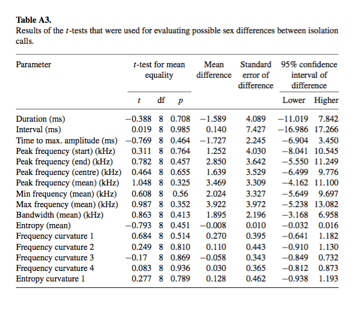